# Climate Change: Day 3

September 2, 2014

Readings: [National Climate Assessment](http://nca2014.globalchange.gov/)

For the first exam, read the entire *Highlights* section. In the *Report* section read the subsection entitled *Our Changing Climate* including the *Climate Science Supplement* (PDF).

Term project: **graph and interpret climate change data**. Bellamy 35 computer lab. R/RStudio installed. Email Shawn Lewers (slewers@fsu.edu)

### Today

[Poll Everywhere](http://www.polleverywhere.com/)

- Heat
- Structure & Composition of the Atmosphere
- Temperature graphs

### Global Warming is About Heat

Heat is proportional to the kinetic (motion) energy of the molecules.

Energy ~ d/2 x k T,

where T is temperature, k is the Boltzmann constant and d is the degrees of freedom of the molecule.

### Why is CO2 a greenhouse gas, but not Argon?

Ar (d = 3), O2/N2 (d = 6, 1 vibrational, 2 twisting), CO2 (d = 9)

Insulating thermal pane windows.

### Pressure and Temperature

The atmosphere is primarily a mixture of gases. N2, O2, Ar, water vapor, CO2, etc.

- The early atmosphere gases included water vapor, CO2, and ammonia (NH3). From where? What happened?

Under pressure: *Why doesn't the sky fall?*

- Balance of forces
- What forces?

Temperature lapse rates.

### Temperature Graphs

### Online resources

[How hot has the summer been?](http://www.climatecentral.org/news/us-summer-temperatures-comparison-17942)

### Using R

[Get R](http://vimeo.com/104869860)

[Get RStudio](https://vimeo.com/104872028)

### Get Temperature Data

[National Climate Assessment](http://nca2014.globalchange.gov/)

### R Code

```r
L1 = 'ftp://ftp.ncdc.noaa.gov/pub/data/'
L2 = 'mlost/operational/products/aravg'
L3 = '.ann.land.00N.90N.v3.5.4.201407.asc'
L = paste(L1, L2, L3, sep = "")
df = read.table(L)
names(df) = c("Year", "Temperature", "Anom")
df[1:3, 1:2]
```

```
  Year Temperature
1 1880     -0.8265
2 1881     -0.7903
3 1882     -0.7668
```

### Install Plotting Package

```r
chooseCRANmirror(ind = 1)
install.packages('ggplot2')
library(ggplot2)
```

### Plot Temperature Data

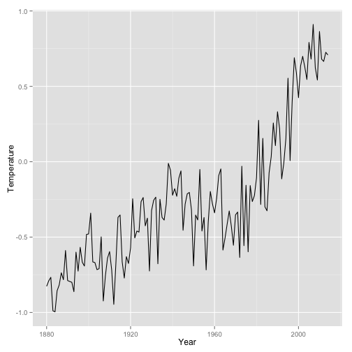

```r
library(ggplot2)
ggplot(df, aes(x = Year, y = Temperature)) +
  geom_line()
```

### Improve Plot

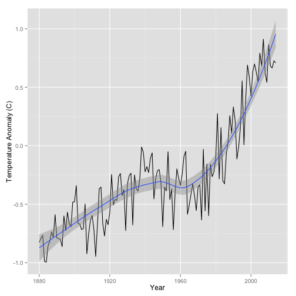

```r
ggplot(df, aes(x = Year, y = Temperature)) +
  geom_line() + geom_smooth() +
  ylab("Temperature Anomaly (C)")
```

### Not Just the Average

Temperature distribution, exceedance frequency, correlation.

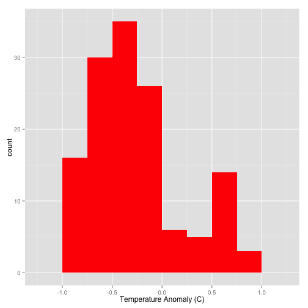

```r
ggplot(df, aes(Temperature)) +
  geom_histogram(binwidth = .25, fill = "red") +
  xlab("Temperature Anomaly (C)")
```

### Is Florida Getting Warmer?

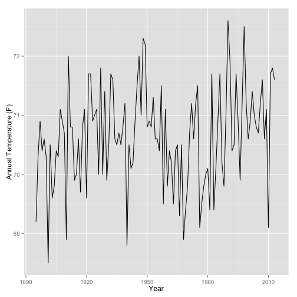

```r
L = 'http://myweb.fsu.edu/jelsner/data/FLMonthlyT.txt'
df = read.table(L, header = TRUE)
ggplot(df, aes(x = Year, y = Annual)) +
  geom_line() + ylab("Annual Temperature (F)")
```